# 03 Bivarijantna analiza

```python
import pandas as pd
import matplotlib.pyplot as plt
```

## U univarijantnoj analizi proučavamo jednu varijablu i njenu distribuciju

## U bivarijantnoj analizi proučavamo odnos između dvije varijable. Postoji li te ako postoji odnos,kakav je? Događa li se pri rastu jedne varijable i rast druge ili pak pad druge varijable

```python
marketing = pd.read_csv ("Advertising.csv")
```

```python
marketing.head()
```

|  | Unnamed: 0 | TV | radio | newspaper | sales |
| --- | --- | --- | --- | --- | --- |
| 0 | 1 | 230.1 | 37.8 | 69.2 | 22.1 |
| 1 | 2 | 44.5 | 39.3 | 45.1 | 10.4 |
| 2 | 3 | 17.2 | 45.9 | 69.3 | 9.3 |
| 3 | 4 | 151.5 | 41.3 | 58.5 | 18.5 |
| 4 | 5 | 180.8 | 10.8 | 58.4 | 12.9 |

## U datasetu Advertising imamo podatke o ulaganju u marketing na televiziji, radiju, novinama (jedinični iznosi) s jedne strane te posljedično prodaja (u tisućama)

## Želimo provjeriti događa li se rast prodaje ako ulažemo u oglašavanje

```python
marketing.describe()
```

|  | Unnamed: 0 | TV | radio | newspaper | sales |
| --- | --- | --- | --- | --- | --- |
| count | 200.000000 | 200.000000 | 200.000000 | 200.000000 | 200.000000 |
| mean | 100.500000 | 147.042500 | 23.264000 | 30.554000 | 14.022500 |
| std | 57.879185 | 85.854236 | 14.846809 | 21.778621 | 5.217457 |
| min | 1.000000 | 0.700000 | 0.000000 | 0.300000 | 1.600000 |
| 25% | 50.750000 | 74.375000 | 9.975000 | 12.750000 | 10.375000 |
| 50% | 100.500000 | 149.750000 | 22.900000 | 25.750000 | 12.900000 |
| 75% | 150.250000 | 218.825000 | 36.525000 | 45.100000 | 17.400000 |
| max | 200.000000 | 296.400000 | 49.600000 | 114.000000 | 27.000000 |

```python
marketing.corr(numeric_only=True)
```

|  | Unnamed: 0 | TV | radio | newspaper | sales |
| --- | --- | --- | --- | --- | --- |
| Unnamed: 0 | 1.000000 | 0.017715 | -0.110680 | -0.154944 | -0.051616 |
| TV | 0.017715 | 1.000000 | 0.054809 | 0.056648 | 0.782224 |
| radio | -0.110680 | 0.054809 | 1.000000 | 0.354104 | 0.576223 |
| newspaper | -0.154944 | 0.056648 | 0.354104 | 1.000000 | 0.228299 |
| sales | -0.051616 | 0.782224 | 0.576223 | 0.228299 | 1.000000 |

## Statistička mjera koja nam govori postoji li veza među varijablama zove se korelacija

# **Zadatak 1: u kojem rasponu se kreće korelacija?**

## Dajte po jedan primjer pozitivne korelacije i negativne korelacije!

## Analizirajte prošlu tablicu, kolika je povezanost između oglašavanja na televiziji i prodaje, oglašavanja u novinama i prodaje te oglašavanja na radiju i prodaje?

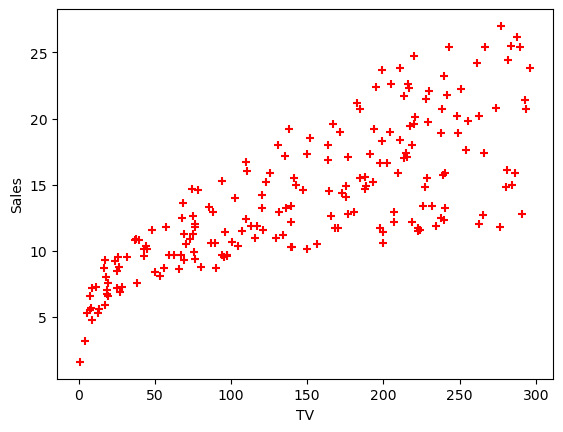

```python
plt.xlabel('TV')
plt.ylabel('Sales')
plt.scatter(marketing.TV, marketing.sales, color='red', marker='+')
```

## Veza među varijablama se može i grafički prikazati korištenjem scatter dijagrama. Za scatter dijagram trebamo dvije varijable

## Objasnite grafikon, što vidimo na njemu

# **Zadatak 2**

## napravite scatter dijagrame u kome ćete prikazati odnos između novina i prodaje te radija i prodaje

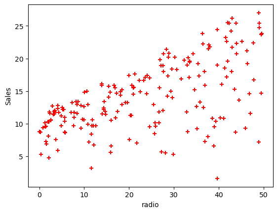

```python
plt.xlabel('radio')
plt.ylabel('Sales')
plt.scatter(marketing.radio, marketing.sales, color='red', marker='+')
```

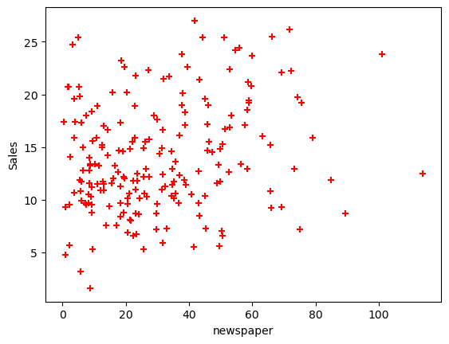

```python
plt.xlabel('newspaper')
plt.ylabel('Sales')
plt.scatter(marketing.newspaper, marketing.sales, color='red', marker='+')
```

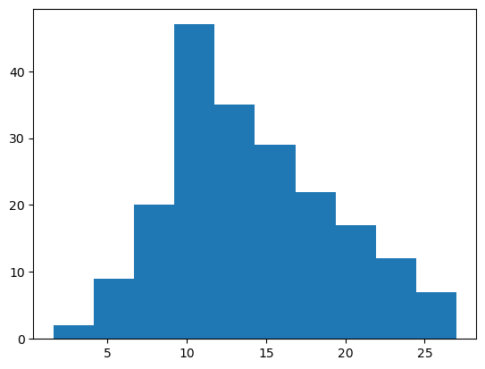

```python
plt.hist (marketing.sales)
```

## Ako otkrijemo korelaciju između dvije varijable, možemo li baš svaki put reći da postoji veza? Moramo li koji put uključiti i domain knowledge expertise?

## Primjeri korelacija koji nemaju smisla

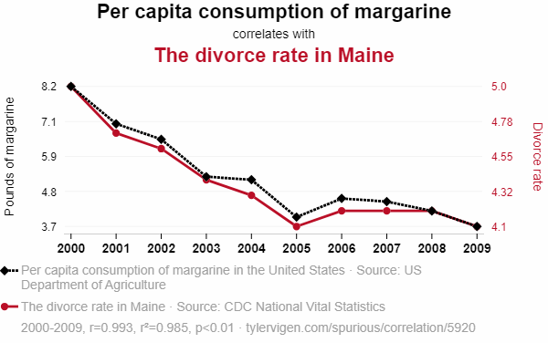

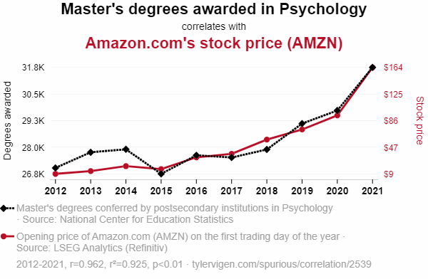

## Još primjera se može naći na ovom linku Spurious correlations :(https://www.tylervigen.com/spurious-correlations)

# **Zadatak 3**

## učitajte notebook u kome obrađujete Titanic dataset.

## napravite scatter dijagrame za varijable Age & Fare te Pclass & Fare. Postoje li veze među tim varijablama?

```python
marketing.corr(numeric_only = True)
```

|  | Unnamed: 0 | TV | radio | newspaper | sales |
| --- | --- | --- | --- | --- | --- |
| Unnamed: 0 | 1.000000 | 0.017715 | -0.110680 | -0.154944 | -0.051616 |
| TV | 0.017715 | 1.000000 | 0.054809 | 0.056648 | 0.782224 |
| radio | -0.110680 | 0.054809 | 1.000000 | 0.354104 | 0.576223 |
| newspaper | -0.154944 | 0.056648 | 0.354104 | 1.000000 | 0.228299 |
| sales | -0.051616 | 0.782224 | 0.576223 | 0.228299 | 1.000000 |

## Upozorenje: ponekad pri provođenju EDA, dolazi do pogreške uzorkovane lijenošću. Koristi se samo naredba corr() za otkrivanje korelacije, bez korištenja grafičkog prikaza za bivarijantnu analizu. Može doći do ozbiljne pogreške jer nam naredba corr() ne pokazuje kako su podaci distribuirani.

```python
df1 = pd.read_excel ("Anscombe.xlsx", sheet_name = "prvi")
df2 = pd.read_excel ("Anscombe.xlsx", sheet_name = "drugi")
df3 = pd.read_excel ("Anscombe.xlsx", sheet_name = "treci")
df4 = pd.read_excel ("Anscombe.xlsx", sheet_name = "cetvrti")
```

## Učitavamo Excel file Anscombe koji ima četiri radna lista, na svakom je posebna tablica. Svaka tablica se učitava u zaseban dataset df1, df2, df3 i df4.

```python
df1.head()
```

|  | x | y |
| --- | --- | --- |
| 0 | 10 | 8.04 |
| 1 | 8 | 6.95 |
| 2 | 13 | 7.58 |
| 3 | 9 | 8.81 |
| 4 | 11 | 8.33 |

```python
df2.head()
```

|  | x | y |
| --- | --- | --- |
| 0 | 10 | 9.14 |
| 1 | 8 | 8.14 |
| 2 | 13 | 8.74 |
| 3 | 9 | 8.77 |
| 4 | 11 | 9.26 |

```python
df1.describe()
```

|  | x | y |
| --- | --- | --- |
| count | 11.000000 | 11.000000 |
| mean | 9.000000 | 7.500909 |
| std | 3.316625 | 2.031568 |
| min | 4.000000 | 4.260000 |
| 25% | 6.500000 | 6.315000 |
| 50% | 9.000000 | 7.580000 |
| 75% | 11.500000 | 8.570000 |
| max | 14.000000 | 10.840000 |

```python
df2.describe()
```

|  | x | y |
| --- | --- | --- |
| count | 11.000000 | 11.000000 |
| mean | 9.000000 | 7.500909 |
| std | 3.316625 | 2.031657 |
| min | 4.000000 | 3.100000 |
| 25% | 6.500000 | 6.695000 |
| 50% | 9.000000 | 8.140000 |
| 75% | 11.500000 | 8.950000 |
| max | 14.000000 | 9.260000 |

```python
df3.describe()
```

|  | x | y |
| --- | --- | --- |
| count | 11.000000 | 11.000000 |
| mean | 9.000000 | 7.500000 |
| std | 3.316625 | 2.030424 |
| min | 4.000000 | 5.390000 |
| 25% | 6.500000 | 6.250000 |
| 50% | 9.000000 | 7.110000 |
| 75% | 11.500000 | 7.980000 |
| max | 14.000000 | 12.740000 |

```python
df4.describe()
```

|  | x | y |
| --- | --- | --- |
| count | 11.000000 | 11.000000 |
| mean | 9.000000 | 7.500909 |
| std | 3.316625 | 2.030579 |
| min | 8.000000 | 5.250000 |
| 25% | 8.000000 | 6.170000 |
| 50% | 8.000000 | 7.040000 |
| 75% | 8.000000 | 8.190000 |
| max | 19.000000 | 12.500000 |

## Sva četiri dataseta imaju isti prosjek i standardnu devijaciju

```python
df1.corr()
```

|  | x | y |
| --- | --- | --- |
| x | 1.000000 | 0.816421 |
| y | 0.816421 | 1.000000 |

```python
df2.corr()
```

|  | x | y |
| --- | --- | --- |
| x | 1.000000 | 0.816237 |
| y | 0.816237 | 1.000000 |

```python
df3.corr()
```

|  | x | y |
| --- | --- | --- |
| x | 1.000000 | 0.816287 |
| y | 0.816287 | 1.000000 |

```python
df4.corr()
```

|  | x | y |
| --- | --- | --- |
| x | 1.000000 | 0.816521 |
| y | 0.816521 | 1.000000 |

## Sva četiri dataseta imaju i isti koeficijent korelacije. Super, možemo zaključiti da postoji veza između varijable x i y, savršeno za predikciju (linearna regresia rulles!)

## Međutim, ako grafički usporedimo varijable x i y u sva četiri dataseta...

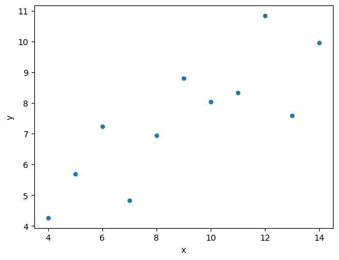

```python
df1.plot (kind = "scatter", x = "x", y = "y")
```

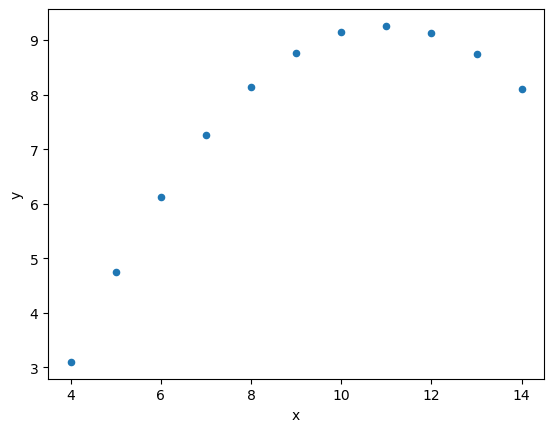

```python
df2.plot (kind = "scatter", x = "x", y = "y")
```

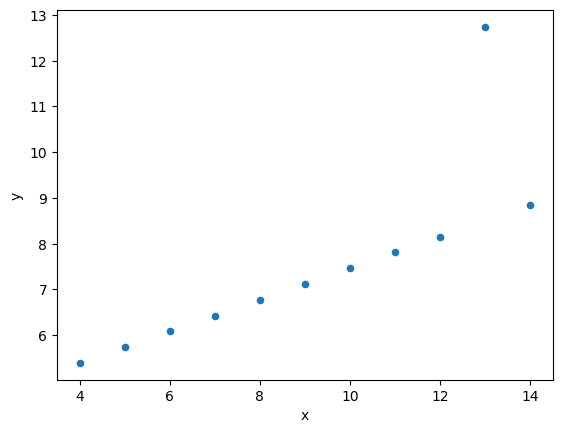

```python
df3.plot (kind = "scatter", x = "x", y = "y")
```

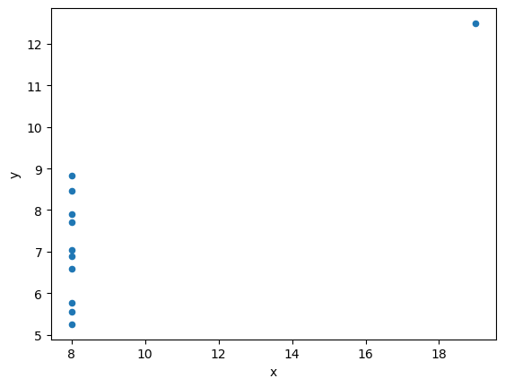

```python
df4.plot (kind = "scatter", x = "x", y = "y")
```

## Ova 4 dataseta (popularno zvana Anscombeov kvartet) nam pokazuju važnost vizualizacije podataka kako se ne bi samo koristile statističke mjere

# correlation does not mean causation!